# Progetto Fondamenti di Scienza dei Dati

## Come nasce il progetto

Il progetto riguardante gli attacchi hacker negli Stati Uniti tra il 2019 e il 2022 nasce per:

- interesse per questo campo
- curiosità personale

Motivi per il quale mi sono posta le seguenti domande:

- Quali stati hanno riscontrato più vittime?
- C’è una correlazione tra numero di vittime e perdite subite dagli stati?
- Quante vittime sono state colpite da attacchi informatici in quegli anni?
- Come sono cambiate le perdite inflitte tra il 2019 e il 2021?
- Come sono cambiate le cose nel 2022?

## Dataset utilizzati

Per sviluppare il progetto sono stati utilizzati i seguenti dataset:

- [Crimini informatici 19-21](https://www.kaggle.com/datasets/ijimakinsamuel/cyber-crimes-in-us-2019-2021)
- Dati2019_2022.xlsx(creato da me)

Prelevati dalle seguenti fonti:

- Kaggle
- IC3 (Internet Crime Complaint Center)

## Quali stati hanno riscontrato più vittime?

Osserviamo quali sono i dieci stati che hanno avuto più vittime:

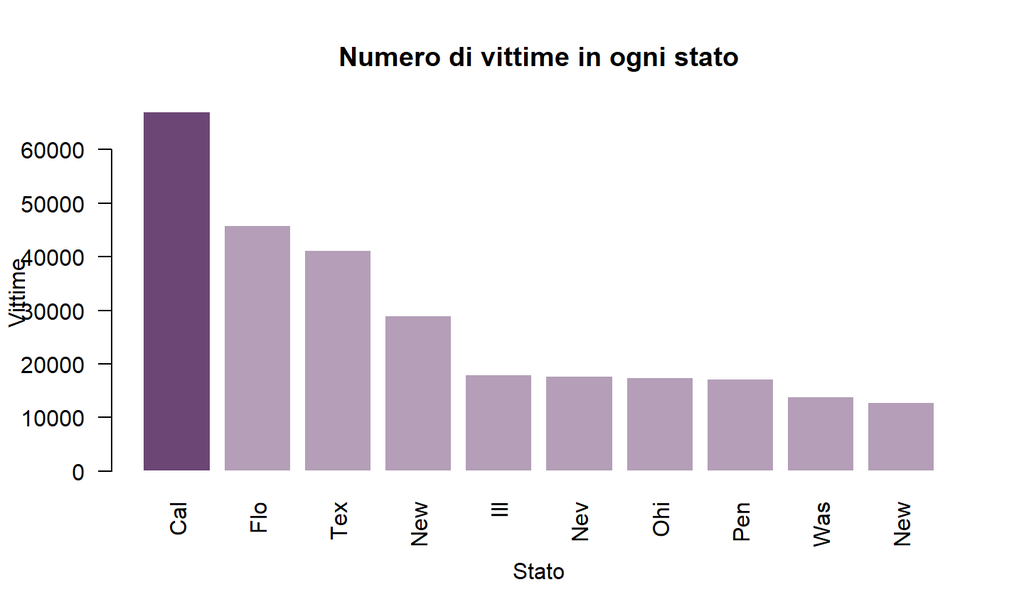

## C’è una correlazione tra numero di vittime e perdite subite dagli stati?

Possiamo osservare ora la correlazione tra numero di vittime e perdite per stato:

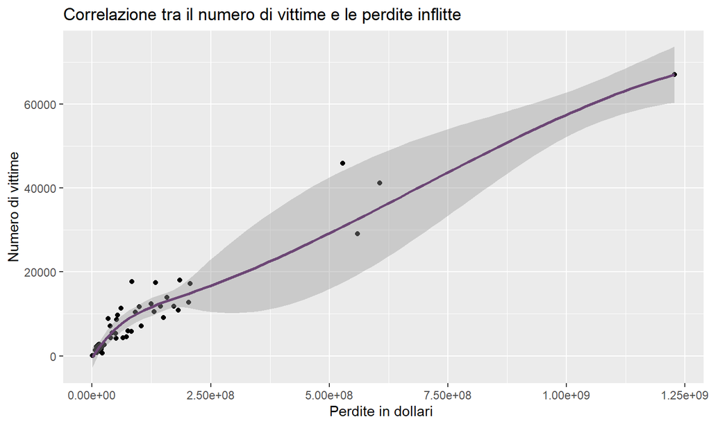

## Quante vittime sono state colpite da attacchi informatici in quegli anni?

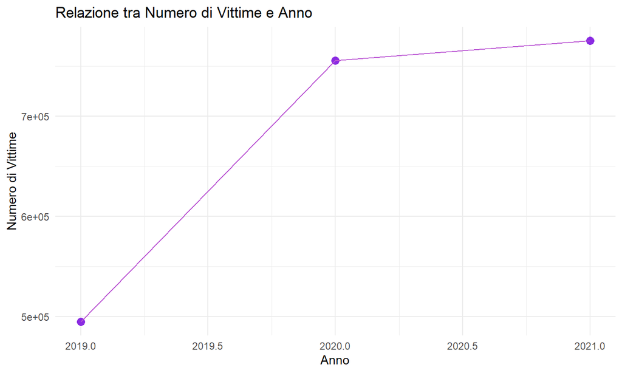

## Come sono cambiate le perdite inflitte tra il 2019 e il 2021?

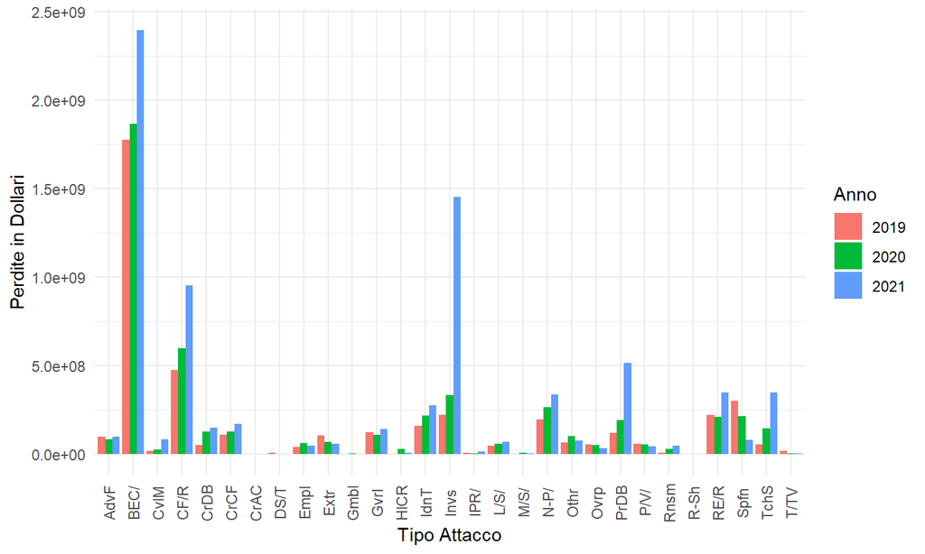

Questo aumento viene messo in risalto se osserviamo le perdite totali

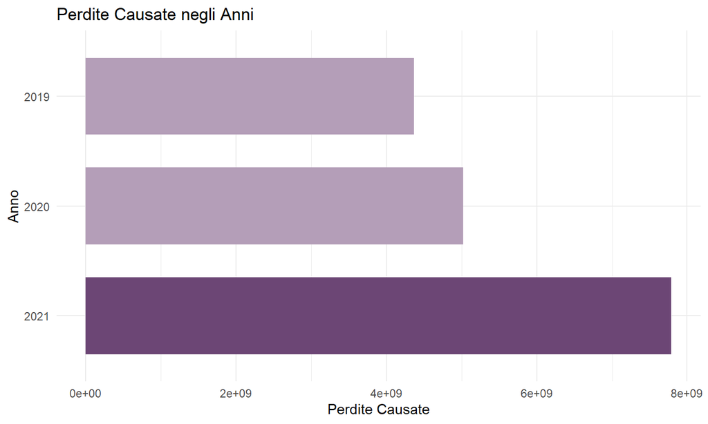

## Come sono cambiate le cose nel 2022?

Presi i dati riguardanti le vittime e le perdite causate da attacchi informatici nell’ultimo anno possiamo dire che:

- Rispetto al 2021 le vittime sono:

```
## # A tibble: 1 × 1
##   Vittime
##     <dbl>
## 1  722302
```

ciò vuol dire che sono diminuite

- Le perdite invece sono:

```
## # A tibble: 1 × 1
##       Perdite
##         <dbl>
## 1 10930600117
```

che sono invece aumentate rispetto agli anni precedenti